# 13 Clustering with ToMATo

This chapter applies ToMATo to two datasets from the FCPS benchmark suite stored locally in this repository. The goal is not to pretend that one set of parameters solves every problem. The goal is to see a consistent workflow in action:

1. load a point cloud;
2. estimate a density;
3. build a proximity graph;
4. inspect peak persistence;
5. choose $\tau$ and cluster.

## 13.1 Setup

```julia
using CairoMakie
using DelimitedFiles
using MetricSpaces
using TDAplots
using ToMATo
```

```julia
function load_fcps(name)
    raw = readdlm("clustering datasets/$name.csv", ',', Any)
    X = EuclideanSpace(permutedims(Float64.(raw[2:end, 2:end])))
    labels = Int.(raw[2:end, 1])
    return X, labels
end
```

```
load_fcps (generic function with 1 method)
```

## 13.2 Target

The `Target` dataset is a good stress test because its clusters are non-convex. This is exactly the kind of situation where methods based on convexity assumptions start to struggle.

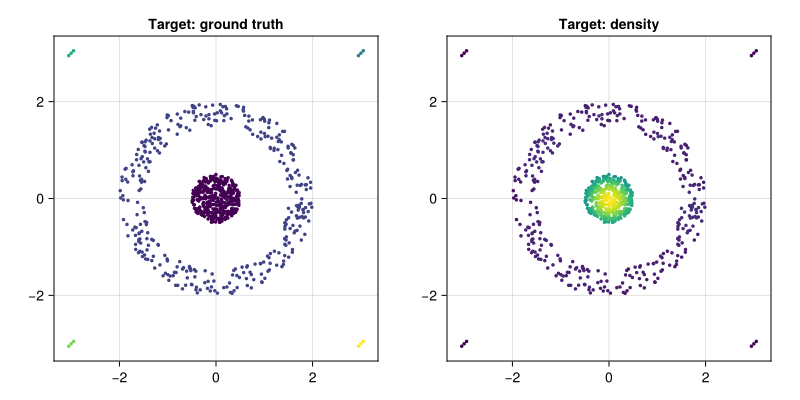

```julia
target_X, target_labels = load_fcps("Target")
target_mat = as_matrix(target_X)

fig = Figure(size = (800, 400))
ax1 = Axis(fig[1, 1], title = "Target: ground truth", aspect = DataAspect())
scatter!(ax1, target_mat[1, :], target_mat[2, :], color = target_labels, markersize = 5)

target_ds = kde(target_X, bandwidth = 0.35)
ax2 = Axis(fig[1, 2], title = "Target: density", aspect = DataAspect())
scatter!(ax2, target_mat[1, :], target_mat[2, :], color = target_ds, markersize = 5)
fig
```

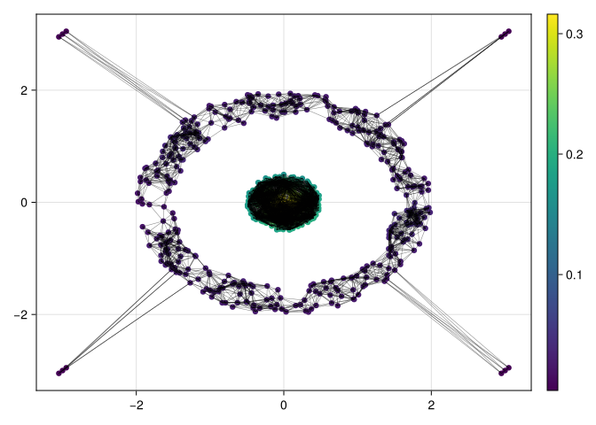

```julia
target_g = proximity_graph(target_X, 0.35; min_k_ball = 5, max_k_ball = 12, k_nn = 5)

tomato_graph_plot(target_X, target_g, target_ds)
```

This graph is the geometric skeleton on which ToMATo will climb the density landscape.

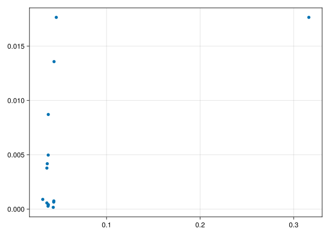

```julia
_, target_births_and_deaths = tomato(target_X, target_g, target_ds, Inf)

tomato_persistence_plot(target_births_and_deaths)
```

As in the previous chapter, the persistence plot tells us which peaks are stable and which ones are just small bumps.

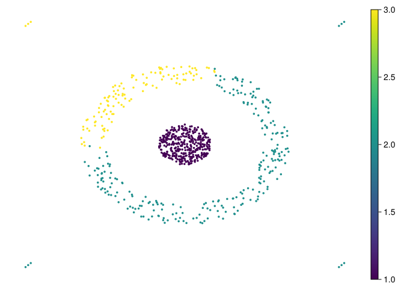

```julia
τ_target = 0.01
target_clusters, _ = tomato(
    target_X,
    target_g,
    target_ds,
    τ_target,
    max_cluster_height = τ_target,
)

metricspace_plot(target_X, color = float.(target_clusters), markersize = 5)
```

## 13.3 Hepta

`Hepta` is a three-dimensional dataset with well-separated dense regions. It is a useful contrast with `Target`: the geometry is simpler, but the data now lives in three dimensions.

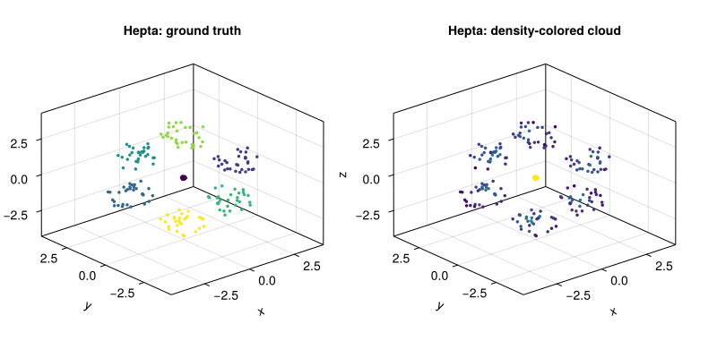

```julia
hepta_X, hepta_labels = load_fcps("Hepta")
hepta_mat = as_matrix(hepta_X)

fig = Figure(size = (800, 400))
ax1 = Axis3(fig[1, 1], title = "Hepta: ground truth")
scatter!(ax1, hepta_mat[1, :], hepta_mat[2, :], hepta_mat[3, :], color = hepta_labels, markersize = 5)

hepta_ds = kde(hepta_X, bandwidth = 0.8)
ax2 = Axis3(fig[1, 2], title = "Hepta: density-colored cloud")
scatter!(ax2, hepta_mat[1, :], hepta_mat[2, :], hepta_mat[3, :], color = hepta_ds, markersize = 5)
fig
```

Here the density picture is more straightforward: several compact high-density regions stand apart clearly.

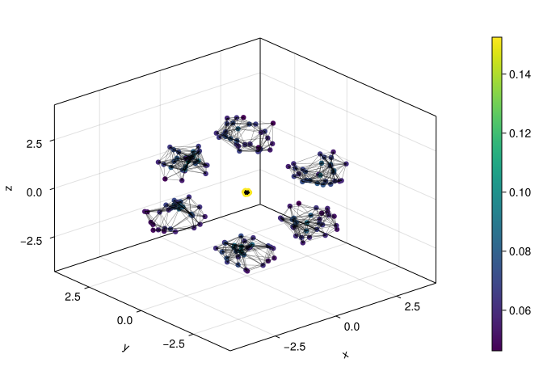

```julia
hepta_g = proximity_graph(hepta_X, 1.0; min_k_ball = 4, max_k_ball = 12, k_nn = 4)

tomato_graph_plot(hepta_X, hepta_g, hepta_ds)
```

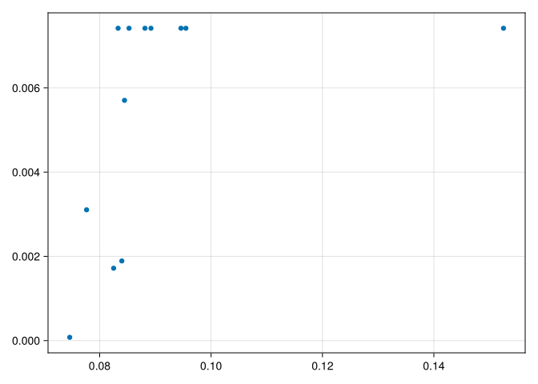

```julia
_, hepta_births_and_deaths = tomato(hepta_X, hepta_g, hepta_ds, Inf)

tomato_persistence_plot(hepta_births_and_deaths)
```

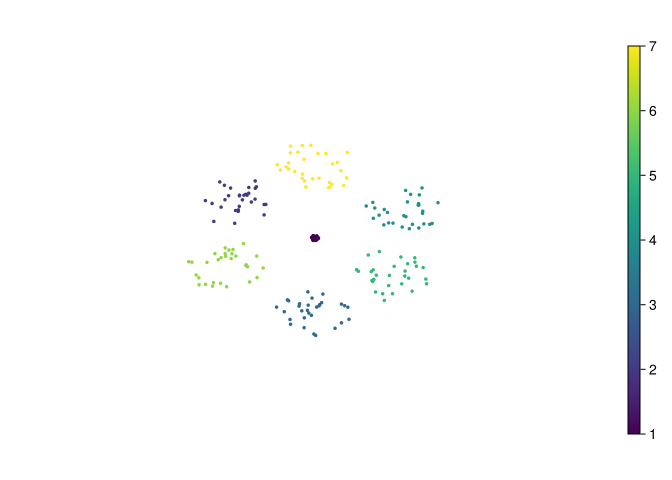

```julia
τ_hepta = 0.02
hepta_clusters, _ = tomato(
    hepta_X,
    hepta_g,
    hepta_ds,
    τ_hepta,
    max_cluster_height = τ_hepta,
)

metricspace_plot(hepta_X, color = float.(hepta_clusters), markersize = 5)
```

Again, the persistence threshold decides how aggressively neighboring peaks are merged.

## 13.4 Remarks

The same recipe appears in both examples, but the parameters change:

- the density bandwidth depends on the scale of the data;
- the proximity radius controls how local the neighborhood graph is;
- the persistence threshold $\tau$ decides how aggressively ToMATo merges peaks.

That is the practical side of ToMATo: the algorithm is simple, but the scale parameters still need to match the geometry of the dataset.

## 13.5 Summary

These two examples illustrate the same practical lesson:

- first inspect the geometry of the data;
- then inspect the density and the peak persistence;
- only then settle on a final threshold $\tau$.

ToMATo is not parameter-free, but it does give you a principled topological diagnostic for choosing how much merging is appropriate.